# Time Series Analysis of PM2.5 in Delhi

### 2. Exploratory data analysis

We collected the data of daily PM2.5 concentration in Delhi from January 2015 to December 2018 [2]. There are 1461 entries with 2 missing points. We impute the missing values by its previous value.

```
##    Min. 1st Qu.  Median    Mean 3rd Qu.    Max.    NA's
##   10.88   62.41  103.93  124.00  164.29  685.36       2
```

After imputing the missing data, we plotted the daily PM2.5 and the its histogram. The results showed that daily PM 2.5 concentration is significantly skewed. It showed that there is no mean stationary and covariance stationary for the data. In addition, the size of the dataset is too large, which might influence our the seasonality analysis[3]. Therefore, we decide to continue decreasing the size of dataset by integrating the mean for each week, and take log transformation.

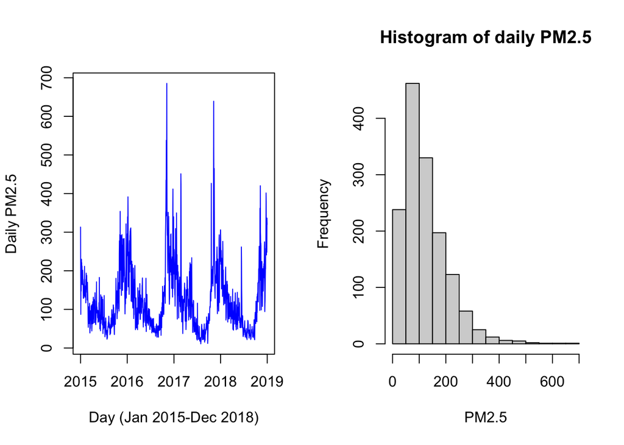

After the log transformation, we also plotted the weekly PM2.5 concentration and its histogram. We saw that the variance of the data is relatively stable, and the mean is nearly constant. In addition, the histogram seems to follow the normal distribution. We used the Shapiro Wilk test (p value =0.053>0.05) to confirm the normal distribution of the dataset.

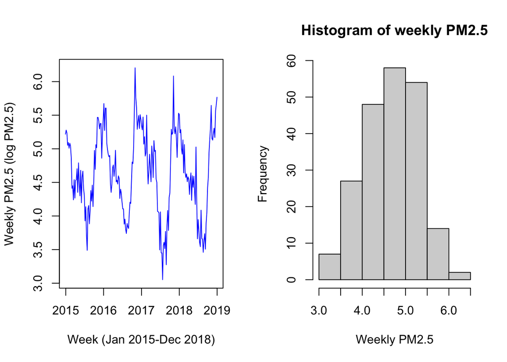

```
##
##  Shapiro-Wilk normality test
##
## data:  Z$PM2.5
## W = 0.98706, p-value = 0.05304
```

Before establishing the ARMA model, we also conducted the spectrum analysis to test the frequency of the log weekly data. First, we plotted the spectrum density, which difficult to interpret. Therefore, we use the periodogram smoother to make the plot more smoother. The peak is around 0.019 to 0.025, which means there might have a cycle around a 0.77 (i.e., 1/0.025/52) to 1 (i.e., 1/0.019/52) year. This validates the visual observation of seasonality, as well as the logical one that PM2.5 would follow a yearly cycle.

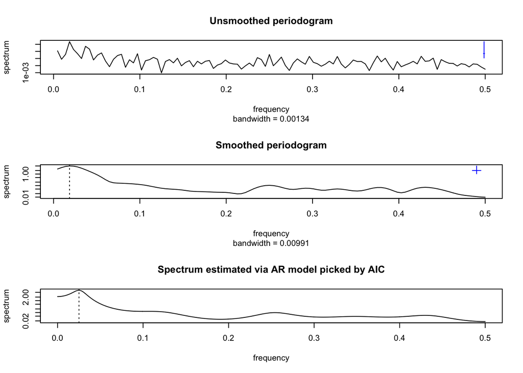

### 3. Model selection and analysis

#### 3.1 ARMA model analysis

As we have already confirmed the weak stationary of the weekly data, we established the general $ARMA(p,q)$ model to fit the data to see the effect. The formula of the general stationary $ARMA(p,q)$ model [3] is

$$\begin{align*}
\phi(B)(Y_n -\mu) = \psi(B)\varepsilon_n
\end{align*}$$

where

$$\begin{align*}
&\mu = \mathbb{E}[Y]\\
&\phi(x) =1 - \phi_1 x - \phi_2 x^2 - \dots - \phi_p x^p\\
&\psi(x) = 1 + \psi_1 x + \psi_2 x^2 + \dots + \psi_p x^p\\
&\varepsilon_{n} \in iid N(0, \sigma^2)
\end{align*}$$

Next, we choose value p and q for $ARMA(p,q)$. Akaike’s information criterion (AIC) is a general approach to select p and q. It is a method to compare likelihoods of different models by penalizing the likelihood of each model by a measure of its complexity. From the AIC table below, when (p,q) = (4,2), (4,1) and (5,2) the model have relatively low AIC values. We consider these three models as our candidates.

|  | MA0 | MA1 | MA2 | MA3 | MA4 | MA5 |
| --- | --- | --- | --- | --- | --- | --- |
| AR0 | 397.75 | 246.76 | 196.19 | 155.59 | 122.44 | 95.85 |
| AR1 | 88.54 | 79.20 | 78.60 | 66.47 | 68.46 | 70.25 |
| AR2 | 78.80 | 80.40 | 79.80 | 68.45 | 68.23 | 69.34 |
| AR3 | 79.69 | 75.93 | 77.83 | 67.87 | 80.46 | 67.18 |
| AR4 | 74.34 | 55.21 | 55.89 | 69.70 | 57.07 | 65.21 |
| AR5 | 70.47 | 56.60 | 55.73 | 57.73 | 67.07 | 65.75 |

We first establish the ARMA(4,2), ARMA(5,2) and ARMA(4,1) models. Result shows all the models are causal and invertible. The roots of ARMA(4,1) are close the the unit root, so we are therefore disregarding.

While the ARMA(4,2) and ARMA(5,2) are very similar, we have decided to go with the simpler model. Therefore, we selected ARMA(4,2) as our candidate.

```
##
## Call:
## arima(x = Z$PM2.5, order = c(4, 0, 2))
##
## Coefficients:
##          ar1     ar2      ar3      ar4      ma1      ma2  intercept
##       0.7746  0.9072  -0.3409  -0.3773  -0.1812  -0.8188     4.6582
## s.e.  0.1198  0.2042   0.1160   0.0643   0.1197   0.1191     0.0146
##
## sigma^2 estimated as 0.06896:  log likelihood = -19.95,  aic = 55.89
```

```
## [1] 1.024588 1.588981 1.588981 1.024588
```

```
## [1] 1.105116 1.105116
```

```
##
## Call:
## arima(x = Z$PM2.5, order = c(5, 0, 2))
##
## Coefficients:
##          ar1     ar2      ar3      ar4      ar5      ma1      ma2  intercept
##       0.6632  0.9909  -0.2879  -0.2915  -0.1165  -0.1043  -0.8957     4.6584
## s.e.  0.1265  0.1752   0.1125   0.0881   0.0819   0.1079   0.1071     0.0134
##
## sigma^2 estimated as 0.06818:  log likelihood = -18.87,  aic = 55.73
```

```
## [1] 1.019756 1.281529 1.019756 2.537503 2.537503
```

```
## [1] 1.056629 1.056629
```

```
##
## Call:
## arima(x = Z$PM2.5, order = c(4, 0, 1))
##
## Coefficients:
##          ar1      ar2     ar3      ar4      ma1  intercept
##       1.5184  -0.3456  0.0137  -0.2117  -0.9754     4.6558
## s.e.  0.0716   0.1263  0.1256   0.0701   0.0347     0.0232
##
## sigma^2 estimated as 0.07006:  log likelihood = -20.6,  aic = 55.21
```

```
## [1] 1.018689 1.018689 2.133523 2.133523
```

```
## [1] 1.025205
```

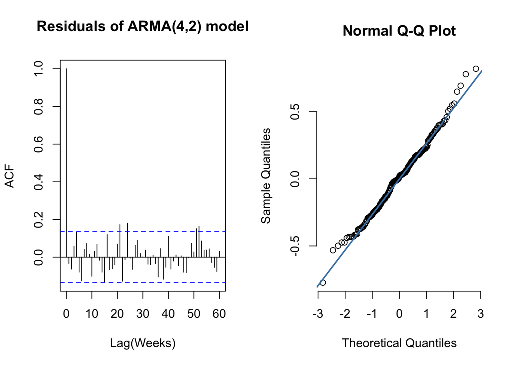

Because there appeared to still be some seasonality in the ACF plot, we are tried to see if adding a difference term improves performance. We see that visually the graphs are comparable, though the log likelihood is lower and the AIC is higher. Also, the MA root is inside the unit circle and is therefore not invertible. The model ARMA(4,2) model looks to be preferred to the ARMA(4,1,2).

```
##
## Call:
## arima(x = Z$PM2.5, order = c(4, 1, 2))
##
## Coefficients:
##           ar1      ar2      ar3     ar4      ma1     ma2
##       -0.0206  -0.8043  -0.1321  0.0406  -0.2989  0.8866
## s.e.   0.0938   0.0887   0.0786  0.0759   0.0647  0.0563
##
## sigma^2 estimated as 0.07652:  log likelihood = -28.42,  aic = 70.84
```

```
## [1] 1.072688 1.072688 3.326770 6.440826
```

```
## [1] 1.2438725 0.9067722
```

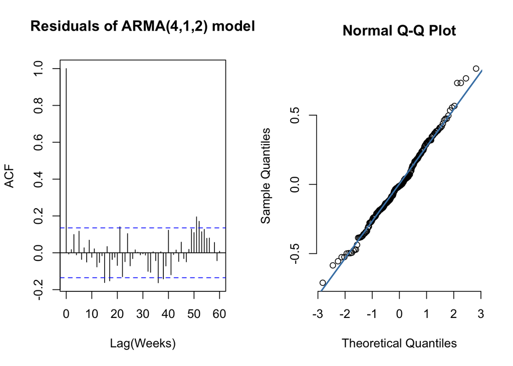

#### 3.2 SARMA model analysis

Due to the imperfection of the ARMA model and frequency plot in 2.2, we also tried the SARMA models. We chose to include a seasonal AR term rather than MA term because we observed a potential seasonal trend both in the spectrum analysis and the ACF analysis of residuals of the ARMA model. We therefore used SARMA(P, Q)(1,0,0) rather than SARMA(P,Q)(1,0,1) model.

From the above specturm density and the acf of the residuals. We select the period of 52. The formula of $SARMA(p,q)\times(1,0,0)_{52}$ model [3] is

$$\begin{align*}
\phi(B)\Phi(B^{52})(Y_n -\mu) = \psi(B)\Psi(B^{52})\varepsilon_n
\end{align*}$$

where

$$\begin{align*}
\mu &= \mathbb{E}[Y]\\
\phi(x) &=1 - \phi_1 x - \phi_2 x^2 - \dots - \phi_p x^p\\
\psi(x) &= 1 + \psi_1 x + \psi_2 x^2 + \dots + \psi_p x^p\\
\Phi(x) &=1 - \Phi_1 x - \Phi_2 x^2 - \dots - \Phi_p x^p\\
\Psi(x) &= 1 + \Psi_1 x + \Psi_2 x^2 + \dots + \Psi_p x^p\\
\varepsilon_{n} &\in iid N(0, \sigma^2)
\end{align*}$$

```
##
## Call:
## arima(x = Z$PM2.5, order = c(4, 0, 2), seasonal = list(order = c(1, 0, 0), period = 52))
##
## Coefficients:
##          ar1      ar2     ar3     ar4      ma1     ma2    sar1  intercept
##       0.7483  -0.7834  0.5403  0.2831  -0.2157  1.0000  0.3413     4.6994
## s.e.  0.0725   0.0770  0.0812  0.0688   0.0132  0.0238  0.0790     0.1978
##
## sigma^2 estimated as 0.06671:  log likelihood = -19.43,  aic = 56.86
```

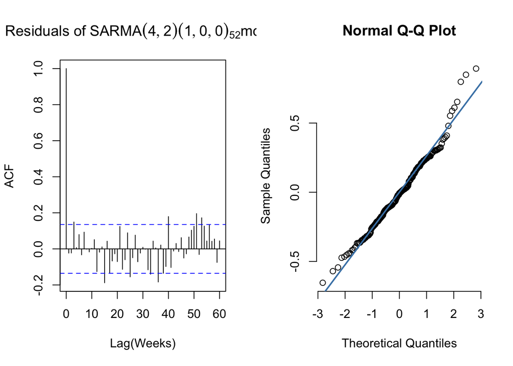

#### 3.3 Likelihood ratio test

To further confirm the necessity to keep the seasonal term in the model, we use the likelihood ratio test. The parameter space of the model is

$$\begin{align*}
H^{<0>}:\theta \in \Theta{(0)}\\
H^{<1>}:\theta \in \Theta{(1)}
\end{align*}$$

where $H^{<0>}$ is the $ARMA(4,2)$ model and $H^{<1>}$ is the $SARMA(4,2)\times(1,0,0)_{52}$ model.

The log likelihood of the $ARMA(4,2)$ model is -19.95, and the log likelihood of the $SARMA(4,2)\times(1,0,0)_{52}$ model is -19.43. The difference of log likelihood is 0.52, which is much smaller than the 1.92 cutoff for a test at 5% size. This means we should not keep the seasonal term. As the lecture 6 mentioned, SARMA model may not work well for the higher frequency data. Thus, we could conclude that $ARMA(4,2)$ fits the data better.

### 5. Reference

1.https://www.who.int/phe/health_topics/outdoorair/outdoorair_aqg/en  
2.https://www.kaggle.com/rohanrao/air-quality-data-in-india  
3.slides on https://ionides.github.io/531w20/